# HW1

Daria Tomina

October 31, 2018

## Работа с данными.

По адресу http://people.math.umass.edu/~anna/Stat597AFall2016/rnf6080.dat можно получить набор данных об осадках в Канаде с 1960 по 1980 годы. Необходимо загрузить эти данные при помощи `read.table`. Воспользуйтесь справкой, чтобы изучить аргументы, которые принимает функция. - Загрузите данные в датафрейм, который назовите `data.df`.

```r
data.df <- read.table("http://people.math.umass.edu/~anna/Stat597AFall2016/rnf6080.dat", header = TRUE)
```

- Сколько строк и столбцов в `data.df`? Если получилось не 5070 наблюдений 27 переменных, то проверяйте аргументы.

```r
nrow(data.df)
```

```
## [1] 5069
```

```r
ncol(data.df)
```

```
## [1] 27
```

- Получите имена колонок из `data.df`.

```r
colnames(data.df)
```

```
##  [1] "X60"   "X4"    "X1"    "X0"    "X0.1"  "X0.2"  "X0.3"  "X0.4"
##  [9] "X0.5"  "X0.6"  "X0.7"  "X0.8"  "X0.9"  "X0.10" "X0.11" "X0.12"
## [17] "X0.13" "X0.14" "X0.15" "X0.16" "X0.17" "X0.18" "X0.19" "X0.20"
## [25] "X0.21" "X0.22" "X0.23"
```

- Найдите значение из 5 строки седьмого столбца.

```r
data.df[5,7]
```

```
## [1] 0
```

- Напечатайте целиком 2 строку из `data.df`

```r
data.df[2,]
```

```
##   X60 X4 X1 X0 X0.1 X0.2 X0.3 X0.4 X0.5 X0.6 X0.7 X0.8 X0.9 X0.10 X0.11
## 2  60  4  3  0    0    0    0    0    0    0    0    0    0     0     0
##   X0.12 X0.13 X0.14 X0.15 X0.16 X0.17 X0.18 X0.19 X0.20 X0.21 X0.22 X0.23
## 2     0     0     0     0     0     0     0     0     0     0     0     0
```

- Объясните, что делает следующая строка кода `names(data.df) <- c("year", "month", "day", seq(0,23))`. Воспользуйтесь функциями `head` и `tail`, чтобы просмотреть таблицу. Что представляют собой последние 24 колонки?

```r
names(data.df) <- c("year", "month", "day", seq(0, 23))
head(data.df)
```

```
##   year month day 0 1 2 3 4 5 6 7 8 9 10 11 12 13 14 15 16 17 18 19 20 21
## 1   60     4   2 0 0 0 0 0 0 0 0 0 0  0  0  0  0  0  0  0  0  0  0  0  0
## 2   60     4   3 0 0 0 0 0 0 0 0 0 0  0  0  0  0  0  0  0  0  0  0  0  0
## 3   60     4   4 0 0 0 0 0 0 0 0 0 0  0  0  0  0  0  0  0  0  0  0  0  0
## 4   60     4   5 0 0 0 0 0 0 0 0 0 0  0  0  0  0  0  0  0  0  0  0  0  0
## 5   60     4   6 0 0 0 0 0 0 0 0 0 0  0  0  0  0  0  0  0  0  0  0  0  0
## 6   60     4   7 0 0 0 0 0 0 0 0 0 0  0  0  0  0  0  0  0  0  0  0  0  0
##   22 23
## 1  0  0
## 2  0  0
## 3  0  0
## 4  0  0
## 5  0  0
## 6  0  0
```

```r
tail(data.df)
```

```
##      year month day 0 1 2 3 4 5 6 7 8 9 10 11 12 13 14 15 16 17 18 19 20
## 5064   80    11  25 0 0 0 0 0 0 0 0 0 0  0  0  0  0  0  0  0  0  0  0  0
## 5065   80    11  26 0 0 0 0 0 0 0 0 0 0  0  0  0  0  0  0  0  0  0  0  0
## 5066   80    11  27 0 0 0 0 0 0 0 0 0 0  0  0  0  0  0  0  0  0  0  0  0
## 5067   80    11  28 0 0 0 0 0 0 0 0 0 0  0  0  0  0  0  0  0  0  0  0  0
## 5068   80    11  29 0 0 0 0 0 0 0 0 0 0  0  0  0  0  0  0  0  0  0  0  0
## 5069   80    11  30 0 0 0 0 0 0 0 0 0 0  0  0  0  0  0  0  0  0  0  0  0
##      21 22 23
## 5064  0  0  0
## 5065  0  0  0
## 5066  0  0  0
## 5067  0  0  0
## 5068  0  0  0
## 5069  0  0  0
```

- Добавьте новую колонку с названием *daily*, в которую запишите сумму крайних правых 24 колонок. Постройте гистограмму по этой колонке. Какие выводы можно сделать?

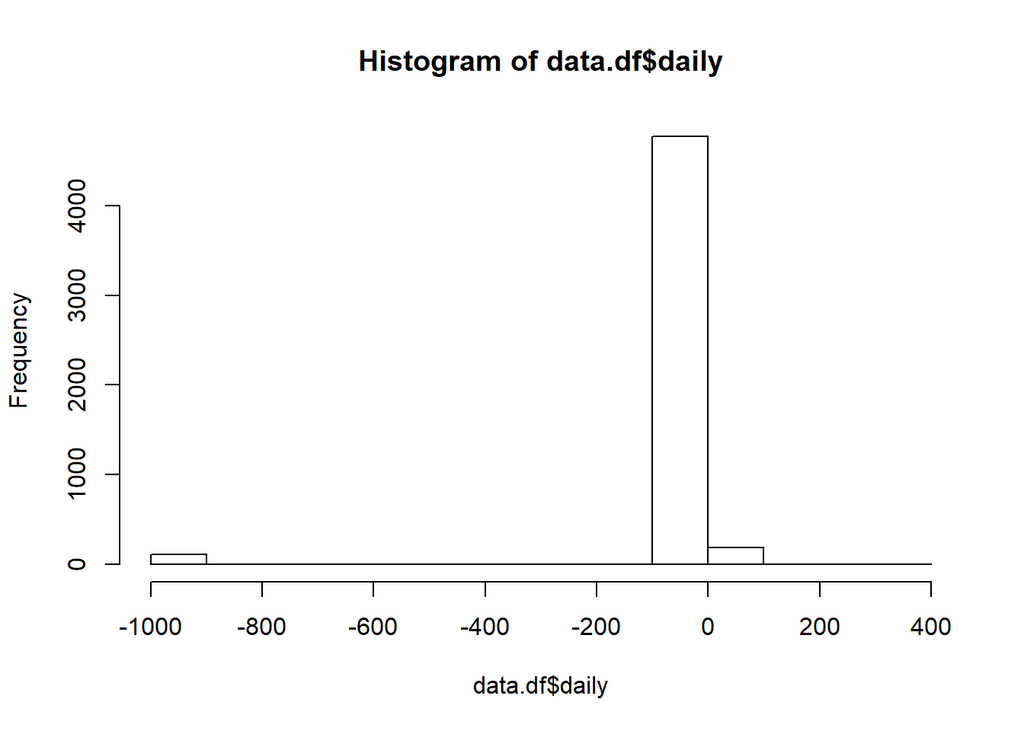

```r
data.df$daily <- rowSums(data.df[length(colnames(data.df)):length(colnames(data.df))-23])
hist(data.df$daily)
```

В данной гистограмме присутствуют отрицательные числа

- Создайте новый датафрейм `fixed.df` в котром исправьте замеченную ошибку. Постройте новую гистограмму, поясните почему она более корректна.

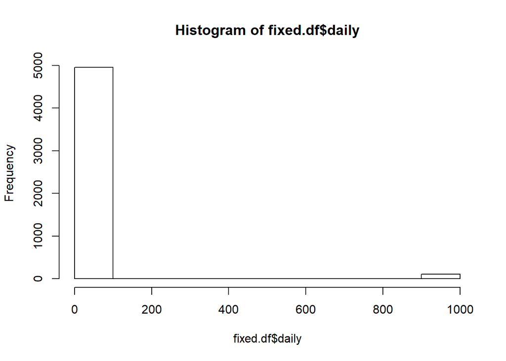

```r
fixed.df <- data.df
fixed.df$daily <- abs(fixed.df$daily)
hist(fixed.df$daily)
```

Количество осадков не может быть отрицательно

## Синтаксис и типизирование

- Для каждой строки кода поясните полученный результат, либо объясните почему она ошибочна.

  ```
  Создаем вектор из строк
  v <- c("4", "8", "15", "16", "23", "42")
  Максимум находится не правильно
  max(v)
  Сортировка происходит не правильно
  sort(v)
  Выдает ошибку из-за неправильного типа данных
  sum(v)
  ```

## Работа с функциями и операторами

- Оператор двоеточие создаёт последовательность целых чисел по порядку. Этот оператор — частный случай функции `seq()`, которую вы использовали раньше. Изучите эту функцию, вызвав команду `?seq`. Испольуя полученные знания выведите на экран:
  1. Числа от 1 до 10000 с инкрементом 372.

```r
seq(1,10000,by=372)
```

```
##  [1]    1  373  745 1117 1489 1861 2233 2605 2977 3349 3721 4093 4465 4837
## [15] 5209 5581 5953 6325 6697 7069 7441 7813 8185 8557 8929 9301 9673
```

```
1. Числа от 1 до 10000 длиной 50.
```

```r
seq(1,10000,length.out=50)
```

```
##  [1]     1.0000   205.0612   409.1224   613.1837   817.2449  1021.3061
##  [7]  1225.3673  1429.4286  1633.4898  1837.5510  2041.6122  2245.6735
## [13]  2449.7347  2653.7959  2857.8571  3061.9184  3265.9796  3470.0408
## [19]  3674.1020  3878.1633  4082.2245  4286.2857  4490.3469  4694.4082
## [25]  4898.4694  5102.5306  5306.5918  5510.6531  5714.7143  5918.7755
## [31]  6122.8367  6326.8980  6530.9592  6735.0204  6939.0816  7143.1429
## [37]  7347.2041  7551.2653  7755.3265  7959.3878  8163.4490  8367.5102
## [43]  8571.5714  8775.6327  8979.6939  9183.7551  9387.8163  9591.8776
## [49]  9795.9388 10000.0000
```

- Функция `rep()` повторяет переданный вектор указанное число раз. Объясните разницу между `rep(1:5,times=3)` и `rep(1:5, each=3)`.

```r
rep(1:5,times=3)
```

```
##  [1] 1 2 3 4 5 1 2 3 4 5 1 2 3 4 5
```

```r
rep(1:5,each=3)
```

```
##  [1] 1 1 1 2 2 2 3 3 3 4 4 4 5 5 5
```